# mphil_ModelComparison

### Section 7. Function to calculate mean RMSE for a gam model for given validation folds

Create function to calcualte the mean rmse for given gam formula and folds

```r
gamMeanErr<- function(folds, formula, name){
  forest[,paste(name,"Err",sep="")] <<- NA
  forest[,paste(name,"Pred",sep="")] <<- NA

  rmseBam <- rep(0, k)
  foreach(i=c(1:k)) %do% {
    test  <- forest[-folds[[i]],]
    train <- forest[folds[[i]],]

    train <-makeARStart(train)
    ggamma <- log(nrow(train))/2

    selectedmod <- bam( formula,
                     data = train,
                     discrete=TRUE,
                     nthreads=8,
                     gamma = ggamma,
                     method="fREML",
                     family = betar,
                     rho=rho,
                     AR.start = arstart )


    pred <- predict(selectedmod, type="response",newdata=test, discrete=FALSE)
    forest[-folds[[i]],][,paste(name,"Pred",sep="")] <<- pred

    err <- rmse(test$nbv_ratio,c(pred))
    paste("prediction RMSE for fold ",i, ":", err)
    rmseBam[i] <- err


  }

  #individual results
  forest[,paste(name,"Err",sep="")] <<- abs(forest$nbv_ratio - forest[,paste(name,"Pred",sep="")] )

  result <- mean(rmseBam)
  paste("RMSE",result )

  return(result)

  }
```

### Section 8: Create function to find RMSE for RF models with given formula and folds

```r
rfMeanErr<- function(folds, formula, name){
  rmseBam <- rep(0, k)
  forest[,paste(name,"Err",sep="")] <<- NA
  forest[,paste(name,"Pred",sep="")] <<- NA

  foreach(i=c(1:k)) %do% {
    test  <- forest[-folds[[i]],]
    train <- forest[folds[[i]],]


    selectedmod <- randomForest(formula, train, importance=FALSE)


    pred <- predict(selectedmod, type="response",newdata=test, discrete=FALSE)
    forest[-folds[[i]],][,paste(name,"Pred",sep="")] <<- pred
    err <- rmse(test$nbv_ratio,c(pred))
    paste("prediction RMSE for fold ",i, ":", err)
    rmseBam[i] <- err
    message(paste("fold",i))
    message(paste("err", err))
    message(paste("rmse bam",rmseBam))

  }

  #individual errors
  forest[,paste(name,"Err",sep="")] <<- abs(forest$nbv_ratio -forest[,paste(name,"Pred",sep="")] )

  #overall error
  result <- mean(rmseBam)
  message(paste("RMSE",result ))

  return(result)
  }
```

### Section 9: Apply general cross validations

```r
df$GAMAge[1] <- gamMeanErr(randomFolds, gamAge, "ranGamAge")
df$RFAge[1]  <- rfMeanErr(randomFolds, rfAge, "ranRfAge" )
```

```
## fold 1
```

```
## err 0.0986740276139087
```

```
## rmse bam 0.0986740276139087rmse bam 0rmse bam 0rmse bam 0rmse bam 0rmse bam 0rmse bam 0rmse bam 0
```

```
## fold 2
```

```
## err 0.0956351011297532
```

```
## rmse bam 0.0986740276139087rmse bam 0.0956351011297532rmse bam 0rmse bam 0rmse bam 0rmse bam 0rmse bam 0rmse bam 0
```

```
## fold 3
```

```
## err 0.0980698233358875
```

```
## rmse bam 0.0986740276139087rmse bam 0.0956351011297532rmse bam 0.0980698233358875rmse bam 0rmse bam 0rmse bam 0rmse bam 0rmse bam 0
```

```
## fold 4
```

```
## err 0.0976565919554988
```

```
## rmse bam 0.0986740276139087rmse bam 0.0956351011297532rmse bam 0.0980698233358875rmse bam 0.0976565919554988rmse bam 0rmse bam 0rmse bam 0rmse bam 0
```

```
## fold 5
```

```
## err 0.102247985047915
```

```
## rmse bam 0.0986740276139087rmse bam 0.0956351011297532rmse bam 0.0980698233358875rmse bam 0.0976565919554988rmse bam 0.102247985047915rmse bam 0rmse bam 0rmse bam 0
```

```
## fold 6
```

```
## err 0.104237297529351
```

```
## rmse bam 0.0986740276139087rmse bam 0.0956351011297532rmse bam 0.0980698233358875rmse bam 0.0976565919554988rmse bam 0.102247985047915rmse bam 0.104237297529351rmse bam 0rmse bam 0
```

```
## fold 7
```

```
## err 0.0997457703110856
```

```
## rmse bam 0.0986740276139087rmse bam 0.0956351011297532rmse bam 0.0980698233358875rmse bam 0.0976565919554988rmse bam 0.102247985047915rmse bam 0.104237297529351rmse bam 0.0997457703110856rmse bam 0
```

```
## fold 8
```

```
## err 0.0977565422834335
```

```
## rmse bam 0.0986740276139087rmse bam 0.0956351011297532rmse bam 0.0980698233358875rmse bam 0.0976565919554988rmse bam 0.102247985047915rmse bam 0.104237297529351rmse bam 0.0997457703110856rmse bam 0.0977565422834335
```

```
## RMSE 0.0992528924008542
```

```r
df$RF0[1]    <- rfMeanErr(randomFolds, rf0,"ranRf0")
```

```
## fold 1
```

```
## err 0.0714325145474657
```

```
## rmse bam 0.0714325145474657rmse bam 0rmse bam 0rmse bam 0rmse bam 0rmse bam 0rmse bam 0rmse bam 0
```

```
## fold 2
```

```
## err 0.070536816845245
```

```
## rmse bam 0.0714325145474657rmse bam 0.070536816845245rmse bam 0rmse bam 0rmse bam 0rmse bam 0rmse bam 0rmse bam 0
```

```
## fold 3
```

```
## err 0.071766992362179
```

```
## rmse bam 0.0714325145474657rmse bam 0.070536816845245rmse bam 0.071766992362179rmse bam 0rmse bam 0rmse bam 0rmse bam 0rmse bam 0
```

```
## fold 4
```

```
## err 0.0722577353901531
```

```
## rmse bam 0.0714325145474657rmse bam 0.070536816845245rmse bam 0.071766992362179rmse bam 0.0722577353901531rmse bam 0rmse bam 0rmse bam 0rmse bam 0
```

```
## fold 5
```

```
## err 0.076070345023104
```

```
## rmse bam 0.0714325145474657rmse bam 0.070536816845245rmse bam 0.071766992362179rmse bam 0.0722577353901531rmse bam 0.076070345023104rmse bam 0rmse bam 0rmse bam 0
```

```
## fold 6
```

```
## err 0.0791085082935006
```

```
## rmse bam 0.0714325145474657rmse bam 0.070536816845245rmse bam 0.071766992362179rmse bam 0.0722577353901531rmse bam 0.076070345023104rmse bam 0.0791085082935006rmse bam 0rmse bam 0
```

```
## fold 7
```

```
## err 0.0723522370550268
```

```
## rmse bam 0.0714325145474657rmse bam 0.070536816845245rmse bam 0.071766992362179rmse bam 0.0722577353901531rmse bam 0.076070345023104rmse bam 0.0791085082935006rmse bam 0.0723522370550268rmse bam 0
```

```
## fold 8
```

```
## err 0.0684561964600191
```

```
## rmse bam 0.0714325145474657rmse bam 0.070536816845245rmse bam 0.071766992362179rmse bam 0.0722577353901531rmse bam 0.076070345023104rmse bam 0.0791085082935006rmse bam 0.0723522370550268rmse bam 0.0684561964600191
```

```
## RMSE 0.0727476682470866
```

```r
df$GAM0[1]   <- gamMeanErr(randomFolds, gam0, "ranGam0")
df$GAM[1]    <- gamMeanErr(randomFolds, gamFull, "ranGamF")
df$RF[1]     <- rfMeanErr(randomFolds, rfFull, "ranRfF")
```

```
## fold 1
```

```
## err 0.0681415146741851
```

```
## rmse bam 0.0681415146741851rmse bam 0rmse bam 0rmse bam 0rmse bam 0rmse bam 0rmse bam 0rmse bam 0
```

```
## fold 2
```

```
## err 0.0692026157100619
```

```
## rmse bam 0.0681415146741851rmse bam 0.0692026157100619rmse bam 0rmse bam 0rmse bam 0rmse bam 0rmse bam 0rmse bam 0
```

```
## fold 3
```

```
## err 0.0685222290953877
```

```
## rmse bam 0.0681415146741851rmse bam 0.0692026157100619rmse bam 0.0685222290953877rmse bam 0rmse bam 0rmse bam 0rmse bam 0rmse bam 0
```

```
## fold 4
```

```
## err 0.0683150108297182
```

```
## rmse bam 0.0681415146741851rmse bam 0.0692026157100619rmse bam 0.0685222290953877rmse bam 0.0683150108297182rmse bam 0rmse bam 0rmse bam 0rmse bam 0
```

```
## fold 5
```

```
## err 0.0763548040599176
```

```
## rmse bam 0.0681415146741851rmse bam 0.0692026157100619rmse bam 0.0685222290953877rmse bam 0.0683150108297182rmse bam 0.0763548040599176rmse bam 0rmse bam 0rmse bam 0
```

```
## fold 6
```

```
## err 0.0769242530430742
```

```
## rmse bam 0.0681415146741851rmse bam 0.0692026157100619rmse bam 0.0685222290953877rmse bam 0.0683150108297182rmse bam 0.0763548040599176rmse bam 0.0769242530430742rmse bam 0rmse bam 0
```

```
## fold 7
```

```
## err 0.0702617545055668
```

```
## rmse bam 0.0681415146741851rmse bam 0.0692026157100619rmse bam 0.0685222290953877rmse bam 0.0683150108297182rmse bam 0.0763548040599176rmse bam 0.0769242530430742rmse bam 0.0702617545055668rmse bam 0
```

```
## fold 8
```

```
## err 0.0676769490550716
```

```
## rmse bam 0.0681415146741851rmse bam 0.0692026157100619rmse bam 0.0685222290953877rmse bam 0.0683150108297182rmse bam 0.0763548040599176rmse bam 0.0769242530430742rmse bam 0.0702617545055668rmse bam 0.0676769490550716
```

```
## RMSE 0.0706748913716229
```

#Error in rfMeanErr(randomFolds, rfAge, “ranRfAge”) : unused argument (“ranRfAge”) # need to fix k in gam models

### Section 10: Apply locationFolds Cross Validation (a)

```r
df$GAMAge[2] <- gamMeanErr(locationFolds, gamAge, "locGamAge")
df$RFAge[2]  <- rfMeanErr(locationFolds, rfAge, "locRfAge")
```

```
## fold 1
```

```
## err 0.0952264192346483
```

```
## rmse bam 0.0952264192346483rmse bam 0rmse bam 0rmse bam 0rmse bam 0rmse bam 0rmse bam 0rmse bam 0
```

```
## fold 2
```

```
## err 0.0929851714465769
```

```
## rmse bam 0.0952264192346483rmse bam 0.0929851714465769rmse bam 0rmse bam 0rmse bam 0rmse bam 0rmse bam 0rmse bam 0
```

```
## fold 3
```

```
## err 0.0976549123795876
```

```
## rmse bam 0.0952264192346483rmse bam 0.0929851714465769rmse bam 0.0976549123795876rmse bam 0rmse bam 0rmse bam 0rmse bam 0rmse bam 0
```

```
## fold 4
```

```
## err 0.0851376326021434
```

```
## rmse bam 0.0952264192346483rmse bam 0.0929851714465769rmse bam 0.0976549123795876rmse bam 0.0851376326021434rmse bam 0rmse bam 0rmse bam 0rmse bam 0
```

```
## fold 5
```

```
## err 0.109948332150471
```

```
## rmse bam 0.0952264192346483rmse bam 0.0929851714465769rmse bam 0.0976549123795876rmse bam 0.0851376326021434rmse bam 0.109948332150471rmse bam 0rmse bam 0rmse bam 0
```

```
## fold 6
```

```
## err 0.107911111077762
```

```
## rmse bam 0.0952264192346483rmse bam 0.0929851714465769rmse bam 0.0976549123795876rmse bam 0.0851376326021434rmse bam 0.109948332150471rmse bam 0.107911111077762rmse bam 0rmse bam 0
```

```
## fold 7
```

```
## err 0.103586414540069
```

```
## rmse bam 0.0952264192346483rmse bam 0.0929851714465769rmse bam 0.0976549123795876rmse bam 0.0851376326021434rmse bam 0.109948332150471rmse bam 0.107911111077762rmse bam 0.103586414540069rmse bam 0
```

```
## fold 8
```

```
## err 0.103115449361417
```

```
## rmse bam 0.0952264192346483rmse bam 0.0929851714465769rmse bam 0.0976549123795876rmse bam 0.0851376326021434rmse bam 0.109948332150471rmse bam 0.107911111077762rmse bam 0.103586414540069rmse bam 0.103115449361417
```

```
## RMSE 0.0994456803490845
```

```r
df$RF0[2]    <- rfMeanErr(locationFolds, rf0, "locRf0")
```

```
## fold 1
```

```
## err 0.0970933536898399
```

```
## rmse bam 0.0970933536898399rmse bam 0rmse bam 0rmse bam 0rmse bam 0rmse bam 0rmse bam 0rmse bam 0
```

```
## fold 2
```

```
## err 0.0870913125583648
```

```
## rmse bam 0.0970933536898399rmse bam 0.0870913125583648rmse bam 0rmse bam 0rmse bam 0rmse bam 0rmse bam 0rmse bam 0
```

```
## fold 3
```

```
## err 0.0903361250800865
```

```
## rmse bam 0.0970933536898399rmse bam 0.0870913125583648rmse bam 0.0903361250800865rmse bam 0rmse bam 0rmse bam 0rmse bam 0rmse bam 0
```

```
## fold 4
```

```
## err 0.0801972152966936
```

```
## rmse bam 0.0970933536898399rmse bam 0.0870913125583648rmse bam 0.0903361250800865rmse bam 0.0801972152966936rmse bam 0rmse bam 0rmse bam 0rmse bam 0
```

```
## fold 5
```

```
## err 0.108182358328912
```

```
## rmse bam 0.0970933536898399rmse bam 0.0870913125583648rmse bam 0.0903361250800865rmse bam 0.0801972152966936rmse bam 0.108182358328912rmse bam 0rmse bam 0rmse bam 0
```

```
## fold 6
```

```
## err 0.0979776749724173
```

```
## rmse bam 0.0970933536898399rmse bam 0.0870913125583648rmse bam 0.0903361250800865rmse bam 0.0801972152966936rmse bam 0.108182358328912rmse bam 0.0979776749724173rmse bam 0rmse bam 0
```

```
## fold 7
```

```
## err 0.098951450697369
```

```
## rmse bam 0.0970933536898399rmse bam 0.0870913125583648rmse bam 0.0903361250800865rmse bam 0.0801972152966936rmse bam 0.108182358328912rmse bam 0.0979776749724173rmse bam 0.098951450697369rmse bam 0
```

```
## fold 8
```

```
## err 0.0975712908238892
```

```
## rmse bam 0.0970933536898399rmse bam 0.0870913125583648rmse bam 0.0903361250800865rmse bam 0.0801972152966936rmse bam 0.108182358328912rmse bam 0.0979776749724173rmse bam 0.098951450697369rmse bam 0.0975712908238892
```

```
## RMSE 0.0946750976809465
```

```r
df$GAM0[2]   <- gamMeanErr(locationFolds, gam0, "locGam0")
df$GAM[2]    <- gamMeanErr(locationFolds, gamFull, "locGamF")
df$RF[2]     <- rfMeanErr(locationFolds, rfFull, "locRfF")
```

```
## fold 1
```

```
## err 0.0899952636418995
```

```
## rmse bam 0.0899952636418995rmse bam 0rmse bam 0rmse bam 0rmse bam 0rmse bam 0rmse bam 0rmse bam 0
```

```
## fold 2
```

```
## err 0.0918289068282397
```

```
## rmse bam 0.0899952636418995rmse bam 0.0918289068282397rmse bam 0rmse bam 0rmse bam 0rmse bam 0rmse bam 0rmse bam 0
```

```
## fold 3
```

```
## err 0.0892409966145155
```

```
## rmse bam 0.0899952636418995rmse bam 0.0918289068282397rmse bam 0.0892409966145155rmse bam 0rmse bam 0rmse bam 0rmse bam 0rmse bam 0
```

```
## fold 4
```

```
## err 0.0761173720571583
```

```
## rmse bam 0.0899952636418995rmse bam 0.0918289068282397rmse bam 0.0892409966145155rmse bam 0.0761173720571583rmse bam 0rmse bam 0rmse bam 0rmse bam 0
```

```
## fold 5
```

```
## err 0.104782267421394
```

```
## rmse bam 0.0899952636418995rmse bam 0.0918289068282397rmse bam 0.0892409966145155rmse bam 0.0761173720571583rmse bam 0.104782267421394rmse bam 0rmse bam 0rmse bam 0
```

```
## fold 6
```

```
## err 0.0991041017354965
```

```
## rmse bam 0.0899952636418995rmse bam 0.0918289068282397rmse bam 0.0892409966145155rmse bam 0.0761173720571583rmse bam 0.104782267421394rmse bam 0.0991041017354965rmse bam 0rmse bam 0
```

```
## fold 7
```

```
## err 0.0947746763572714
```

```
## rmse bam 0.0899952636418995rmse bam 0.0918289068282397rmse bam 0.0892409966145155rmse bam 0.0761173720571583rmse bam 0.104782267421394rmse bam 0.0991041017354965rmse bam 0.0947746763572714rmse bam 0
```

```
## fold 8
```

```
## err 0.0938797816222769
```

```
## rmse bam 0.0899952636418995rmse bam 0.0918289068282397rmse bam 0.0892409966145155rmse bam 0.0761173720571583rmse bam 0.104782267421394rmse bam 0.0991041017354965rmse bam 0.0947746763572714rmse bam 0.0938797816222769
```

```
## RMSE 0.0924654207847815
```

### Section 11: Apply timeFolds cross validation

```r
df$GAMAge[3] <- gamMeanErr(timeFolds, gamAge, "timGamAge")
df$RFAge[3]  <- rfMeanErr(timeFolds, rfAge, "timRfAge" )
```

```
## fold 1
```

```
## err 0.105081883740761
```

```
## rmse bam 0.105081883740761rmse bam 0rmse bam 0rmse bam 0rmse bam 0rmse bam 0rmse bam 0rmse bam 0
```

```
## fold 2
```

```
## err 0.0959585883389956
```

```
## rmse bam 0.105081883740761rmse bam 0.0959585883389956rmse bam 0rmse bam 0rmse bam 0rmse bam 0rmse bam 0rmse bam 0
```

```
## fold 3
```

```
## err 0.108641216487889
```

```
## rmse bam 0.105081883740761rmse bam 0.0959585883389956rmse bam 0.108641216487889rmse bam 0rmse bam 0rmse bam 0rmse bam 0rmse bam 0
```

```
## fold 4
```

```
## err 0.0878386169608366
```

```
## rmse bam 0.105081883740761rmse bam 0.0959585883389956rmse bam 0.108641216487889rmse bam 0.0878386169608366rmse bam 0rmse bam 0rmse bam 0rmse bam 0
```

```
## fold 5
```

```
## err 0.0957205210919758
```

```
## rmse bam 0.105081883740761rmse bam 0.0959585883389956rmse bam 0.108641216487889rmse bam 0.0878386169608366rmse bam 0.0957205210919758rmse bam 0rmse bam 0rmse bam 0
```

```
## fold 6
```

```
## err 0.102264367611501
```

```
## rmse bam 0.105081883740761rmse bam 0.0959585883389956rmse bam 0.108641216487889rmse bam 0.0878386169608366rmse bam 0.0957205210919758rmse bam 0.102264367611501rmse bam 0rmse bam 0
```

```
## fold 7
```

```
## err 0.103710290453836
```

```
## rmse bam 0.105081883740761rmse bam 0.0959585883389956rmse bam 0.108641216487889rmse bam 0.0878386169608366rmse bam 0.0957205210919758rmse bam 0.102264367611501rmse bam 0.103710290453836rmse bam 0
```

```
## fold 8
```

```
## err 0.101127961015823
```

```
## rmse bam 0.105081883740761rmse bam 0.0959585883389956rmse bam 0.108641216487889rmse bam 0.0878386169608366rmse bam 0.0957205210919758rmse bam 0.102264367611501rmse bam 0.103710290453836rmse bam 0.101127961015823
```

```
## RMSE 0.100042930712702
```

```r
df$RF0[3]    <- rfMeanErr(timeFolds, rf0, "timRf0")
```

```
## fold 1
```

```
## err 0.0729946896468921
```

```
## rmse bam 0.0729946896468921rmse bam 0rmse bam 0rmse bam 0rmse bam 0rmse bam 0rmse bam 0rmse bam 0
```

```
## fold 2
```

```
## err 0.0621722138005457
```

```
## rmse bam 0.0729946896468921rmse bam 0.0621722138005457rmse bam 0rmse bam 0rmse bam 0rmse bam 0rmse bam 0rmse bam 0
```

```
## fold 3
```

```
## err 0.072762853322856
```

```
## rmse bam 0.0729946896468921rmse bam 0.0621722138005457rmse bam 0.072762853322856rmse bam 0rmse bam 0rmse bam 0rmse bam 0rmse bam 0
```

```
## fold 4
```

```
## err 0.0552726790222079
```

```
## rmse bam 0.0729946896468921rmse bam 0.0621722138005457rmse bam 0.072762853322856rmse bam 0.0552726790222079rmse bam 0rmse bam 0rmse bam 0rmse bam 0
```

```
## fold 5
```

```
## err 0.0851025021589289
```

```
## rmse bam 0.0729946896468921rmse bam 0.0621722138005457rmse bam 0.072762853322856rmse bam 0.0552726790222079rmse bam 0.0851025021589289rmse bam 0rmse bam 0rmse bam 0
```

```
## fold 6
```

```
## err 0.0677723498982591
```

```
## rmse bam 0.0729946896468921rmse bam 0.0621722138005457rmse bam 0.072762853322856rmse bam 0.0552726790222079rmse bam 0.0851025021589289rmse bam 0.0677723498982591rmse bam 0rmse bam 0
```

```
## fold 7
```

```
## err 0.0782966695724792
```

```
## rmse bam 0.0729946896468921rmse bam 0.0621722138005457rmse bam 0.072762853322856rmse bam 0.0552726790222079rmse bam 0.0851025021589289rmse bam 0.0677723498982591rmse bam 0.0782966695724792rmse bam 0
```

```
## fold 8
```

```
## err 0.083267847085537
```

```
## rmse bam 0.0729946896468921rmse bam 0.0621722138005457rmse bam 0.072762853322856rmse bam 0.0552726790222079rmse bam 0.0851025021589289rmse bam 0.0677723498982591rmse bam 0.0782966695724792rmse bam 0.083267847085537
```

```
## RMSE 0.0722052255634632
```

```r
df$GAM0[3]   <- gamMeanErr(timeFolds, gam0, "timGam0")
df$GAM[3]    <- gamMeanErr(timeFolds, gamFull, "timGamF")
df$RF[3]     <- rfMeanErr(timeFolds, rfFull, "timRfF")
```

```
## fold 1
```

```
## err 0.0710984360946526
```

```
## rmse bam 0.0710984360946526rmse bam 0rmse bam 0rmse bam 0rmse bam 0rmse bam 0rmse bam 0rmse bam 0
```

```
## fold 2
```

```
## err 0.0624984171959076
```

```
## rmse bam 0.0710984360946526rmse bam 0.0624984171959076rmse bam 0rmse bam 0rmse bam 0rmse bam 0rmse bam 0rmse bam 0
```

```
## fold 3
```

```
## err 0.0696985575775543
```

```
## rmse bam 0.0710984360946526rmse bam 0.0624984171959076rmse bam 0.0696985575775543rmse bam 0rmse bam 0rmse bam 0rmse bam 0rmse bam 0
```

```
## fold 4
```

```
## err 0.0519318141669383
```

```
## rmse bam 0.0710984360946526rmse bam 0.0624984171959076rmse bam 0.0696985575775543rmse bam 0.0519318141669383rmse bam 0rmse bam 0rmse bam 0rmse bam 0
```

```
## fold 5
```

```
## err 0.0828685040888437
```

```
## rmse bam 0.0710984360946526rmse bam 0.0624984171959076rmse bam 0.0696985575775543rmse bam 0.0519318141669383rmse bam 0.0828685040888437rmse bam 0rmse bam 0rmse bam 0
```

```
## fold 6
```

```
## err 0.0667691870007997
```

```
## rmse bam 0.0710984360946526rmse bam 0.0624984171959076rmse bam 0.0696985575775543rmse bam 0.0519318141669383rmse bam 0.0828685040888437rmse bam 0.0667691870007997rmse bam 0rmse bam 0
```

```
## fold 7
```

```
## err 0.0775321159540856
```

```
## rmse bam 0.0710984360946526rmse bam 0.0624984171959076rmse bam 0.0696985575775543rmse bam 0.0519318141669383rmse bam 0.0828685040888437rmse bam 0.0667691870007997rmse bam 0.0775321159540856rmse bam 0
```

```
## fold 8
```

```
## err 0.0782455909655402
```

```
## rmse bam 0.0710984360946526rmse bam 0.0624984171959076rmse bam 0.0696985575775543rmse bam 0.0519318141669383rmse bam 0.0828685040888437rmse bam 0.0667691870007997rmse bam 0.0775321159540856rmse bam 0.0782455909655402
```

```
## RMSE 0.0700803278805402
```

### Section 12: Apply timeLocFolds cross validation (b)

```r
df$GAMAge[4] <- gamMeanErr(timeLocFolds, gamAge, "timLocGamAge")
df$RFAge[4]  <- rfMeanErr(timeLocFolds, rfAge, "timLocRfAge" )
```

```
## fold 1
```

```
## err 0.093907531734596
```

```
## rmse bam 0.093907531734596rmse bam 0rmse bam 0rmse bam 0rmse bam 0rmse bam 0rmse bam 0rmse bam 0
```

```
## fold 2
```

```
## err 0.0984202584298635
```

```
## rmse bam 0.093907531734596rmse bam 0.0984202584298635rmse bam 0rmse bam 0rmse bam 0rmse bam 0rmse bam 0rmse bam 0
```

```
## fold 3
```

```
## err 0.0998861082271404
```

```
## rmse bam 0.093907531734596rmse bam 0.0984202584298635rmse bam 0.0998861082271404rmse bam 0rmse bam 0rmse bam 0rmse bam 0rmse bam 0
```

```
## fold 4
```

```
## err 0.0998017147087985
```

```
## rmse bam 0.093907531734596rmse bam 0.0984202584298635rmse bam 0.0998861082271404rmse bam 0.0998017147087985rmse bam 0rmse bam 0rmse bam 0rmse bam 0
```

```
## fold 5
```

```
## err 0.0975480396027841
```

```
## rmse bam 0.093907531734596rmse bam 0.0984202584298635rmse bam 0.0998861082271404rmse bam 0.0998017147087985rmse bam 0.0975480396027841rmse bam 0rmse bam 0rmse bam 0
```

```
## fold 6
```

```
## err 0.09865168124078
```

```
## rmse bam 0.093907531734596rmse bam 0.0984202584298635rmse bam 0.0998861082271404rmse bam 0.0998017147087985rmse bam 0.0975480396027841rmse bam 0.09865168124078rmse bam 0rmse bam 0
```

```
## fold 7
```

```
## err 0.0980439816065335
```

```
## rmse bam 0.093907531734596rmse bam 0.0984202584298635rmse bam 0.0998861082271404rmse bam 0.0998017147087985rmse bam 0.0975480396027841rmse bam 0.09865168124078rmse bam 0.0980439816065335rmse bam 0
```

```
## fold 8
```

```
## err 0.0972293334678658
```

```
## rmse bam 0.093907531734596rmse bam 0.0984202584298635rmse bam 0.0998861082271404rmse bam 0.0998017147087985rmse bam 0.0975480396027841rmse bam 0.09865168124078rmse bam 0.0980439816065335rmse bam 0.0972293334678658
```

```
## RMSE 0.0979360811272952
```

```r
df$RF0[4]    <- rfMeanErr(timeLocFolds, rf0, "timLocRf0")
```

```
## fold 1
```

```
## err 0.0697629205371752
```

```
## rmse bam 0.0697629205371752rmse bam 0rmse bam 0rmse bam 0rmse bam 0rmse bam 0rmse bam 0rmse bam 0
```

```
## fold 2
```

```
## err 0.0787555896365484
```

```
## rmse bam 0.0697629205371752rmse bam 0.0787555896365484rmse bam 0rmse bam 0rmse bam 0rmse bam 0rmse bam 0rmse bam 0
```

```
## fold 3
```

```
## err 0.0652477688326405
```

```
## rmse bam 0.0697629205371752rmse bam 0.0787555896365484rmse bam 0.0652477688326405rmse bam 0rmse bam 0rmse bam 0rmse bam 0rmse bam 0
```

```
## fold 4
```

```
## err 0.071281967048337
```

```
## rmse bam 0.0697629205371752rmse bam 0.0787555896365484rmse bam 0.0652477688326405rmse bam 0.071281967048337rmse bam 0rmse bam 0rmse bam 0rmse bam 0
```

```
## fold 5
```

```
## err 0.0763160672867817
```

```
## rmse bam 0.0697629205371752rmse bam 0.0787555896365484rmse bam 0.0652477688326405rmse bam 0.071281967048337rmse bam 0.0763160672867817rmse bam 0rmse bam 0rmse bam 0
```

```
## fold 6
```

```
## err 0.07471056232374
```

```
## rmse bam 0.0697629205371752rmse bam 0.0787555896365484rmse bam 0.0652477688326405rmse bam 0.071281967048337rmse bam 0.0763160672867817rmse bam 0.07471056232374rmse bam 0rmse bam 0
```

```
## fold 7
```

```
## err 0.068107055921763
```

```
## rmse bam 0.0697629205371752rmse bam 0.0787555896365484rmse bam 0.0652477688326405rmse bam 0.071281967048337rmse bam 0.0763160672867817rmse bam 0.07471056232374rmse bam 0.068107055921763rmse bam 0
```

```
## fold 8
```

```
## err 0.0753736713421788
```

```
## rmse bam 0.0697629205371752rmse bam 0.0787555896365484rmse bam 0.0652477688326405rmse bam 0.071281967048337rmse bam 0.0763160672867817rmse bam 0.07471056232374rmse bam 0.068107055921763rmse bam 0.0753736713421788
```

```
## RMSE 0.0724444503661456
```

```r
df$GAM0[4]   <- gamMeanErr(timeLocFolds, gam0, "timLocGam0")
df$GAM[4]    <- gamMeanErr(timeLocFolds, gamFull, "timLocGamF")
df$RF[4]     <- rfMeanErr(timeLocFolds, rfFull, "timLocRfF")
```

```
## fold 1
```

```
## err 0.0674622622292238
```

```
## rmse bam 0.0674622622292238rmse bam 0rmse bam 0rmse bam 0rmse bam 0rmse bam 0rmse bam 0rmse bam 0
```

```
## fold 2
```

```
## err 0.0766037382871581
```

```
## rmse bam 0.0674622622292238rmse bam 0.0766037382871581rmse bam 0rmse bam 0rmse bam 0rmse bam 0rmse bam 0rmse bam 0
```

```
## fold 3
```

```
## err 0.064520430698873
```

```
## rmse bam 0.0674622622292238rmse bam 0.0766037382871581rmse bam 0.064520430698873rmse bam 0rmse bam 0rmse bam 0rmse bam 0rmse bam 0
```

```
## fold 4
```

```
## err 0.0686046304548156
```

```
## rmse bam 0.0674622622292238rmse bam 0.0766037382871581rmse bam 0.064520430698873rmse bam 0.0686046304548156rmse bam 0rmse bam 0rmse bam 0rmse bam 0
```

```
## fold 5
```

```
## err 0.0757400285055204
```

```
## rmse bam 0.0674622622292238rmse bam 0.0766037382871581rmse bam 0.064520430698873rmse bam 0.0686046304548156rmse bam 0.0757400285055204rmse bam 0rmse bam 0rmse bam 0
```

```
## fold 6
```

```
## err 0.0736953013867219
```

```
## rmse bam 0.0674622622292238rmse bam 0.0766037382871581rmse bam 0.064520430698873rmse bam 0.0686046304548156rmse bam 0.0757400285055204rmse bam 0.0736953013867219rmse bam 0rmse bam 0
```

```
## fold 7
```

```
## err 0.0675803150123878
```

```
## rmse bam 0.0674622622292238rmse bam 0.0766037382871581rmse bam 0.064520430698873rmse bam 0.0686046304548156rmse bam 0.0757400285055204rmse bam 0.0736953013867219rmse bam 0.0675803150123878rmse bam 0
```

```
## fold 8
```

```
## err 0.0727686181822419
```

```
## rmse bam 0.0674622622292238rmse bam 0.0766037382871581rmse bam 0.064520430698873rmse bam 0.0686046304548156rmse bam 0.0757400285055204rmse bam 0.0736953013867219rmse bam 0.0675803150123878rmse bam 0.0727686181822419
```

```
## RMSE 0.0708719155946178
```

### Section 13: Print general results

```r
knitr::kable(df)
```

|  | RFAge | GAMAge | RF0 | GAM0 | RF | GAM |
| --- | --- | --- | --- | --- | --- | --- |
| General cross validation | 0.0992529 | 0.1004378 | 0.0727477 | 0.0990380 | 0.0706749 | 0.0976325 |
| Spatial cross validation | 0.0994457 | 0.1016287 | 0.0946751 | 0.1031942 | 0.0924654 | 0.1016115 |
| Temporal cross validation | 0.1000429 | 0.1011095 | 0.0722052 | 0.1021427 | 0.0700803 | 0.0995158 |
| Temporal/Spatial cross validation | 0.0979361 | 0.0994494 | 0.0724445 | 0.0996504 | 0.0708719 | 0.0979262 |

### Section 14: Create graphs of error by year

Create plots to show error comparison

```r
errorPlots <- function(gamName, rfName, title){
  data <- data.frame(id=forest$id ,year=forest$year,
                     gamerr=forest[,paste(gamName,"Err",sep="")],
                     rferr=forest[,paste(rfName,"Err",sep="")])
  library(reshape)
  meltData <- melt(data, id.vars =c('id', 'year'))

  aggData <- aggregate(value~year+variable, data=meltData, mean)
  aggDataSd <- aggregate(value~year+variable, data=meltData, sd)
  aggData$sd <- aggDataSd$value


  ggplot(aggData, aes(year, value)) + geom_line(aes(colour=variable) )+geom_ribbon(aes(y = value, ymin = value - sd, ymax = value + sd, fill = variable), alpha = .2)+ggtitle(title)+labs(y="Mean Absolute error", x="Year", color="Model")+scale_color_manual(labels = c("GAM Age", "RF Age"), values = c("red", "blue"))+coord_cartesian(ylim = c(0, 0.2))+scale_x_continuous(breaks = scales::pretty_breaks(n = 10)) +
scale_y_continuous(breaks = scales::pretty_breaks(n = 10))

}
```

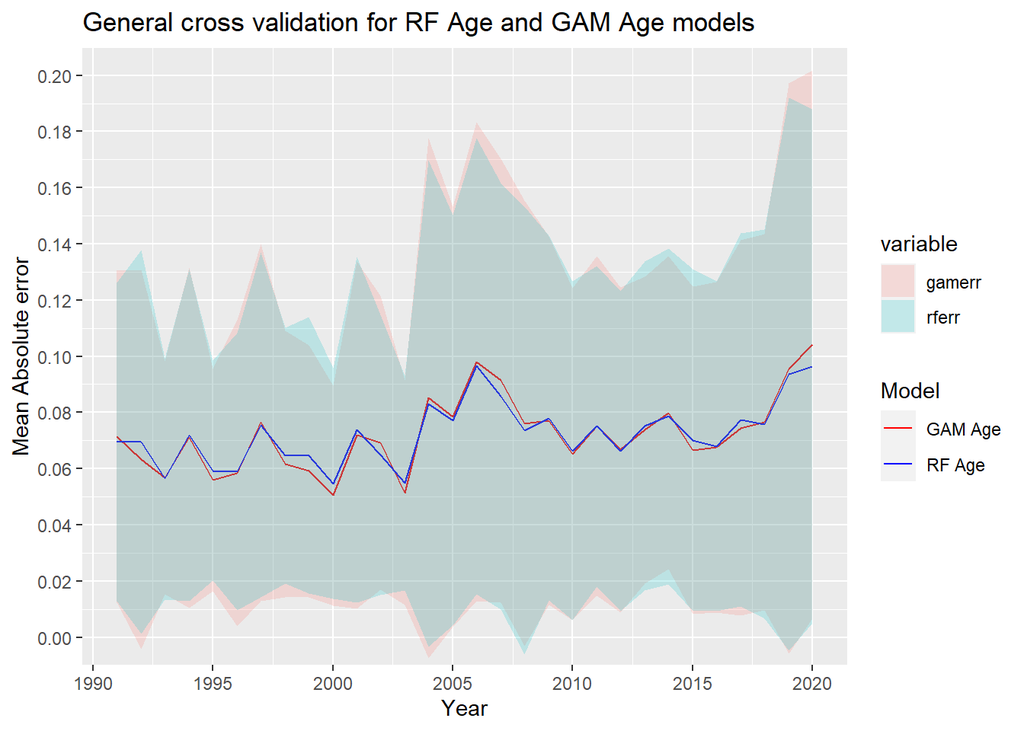

```r
errorPlots("ranGamAge", "ranRfAge", "General cross validation for RF Age and GAM Age models")
```

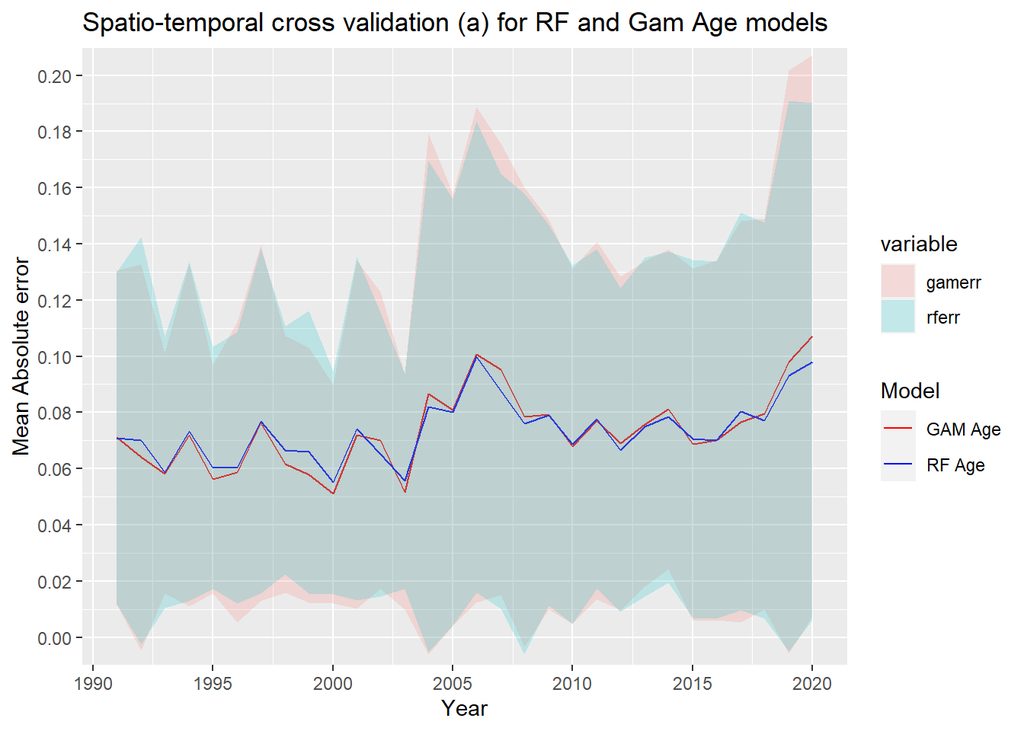

```r
errorPlots("locGamAge", "locRfAge", "Spatio-temporal cross validation (a) for RF and Gam Age models")
```

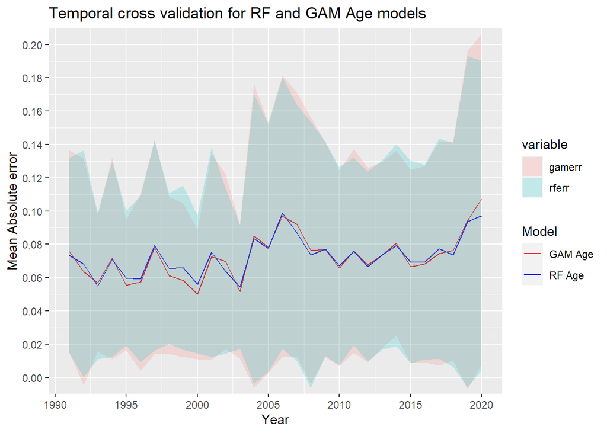

```r
errorPlots("timGamAge", "timRfAge", "Temporal cross validation for RF and GAM Age models")
```

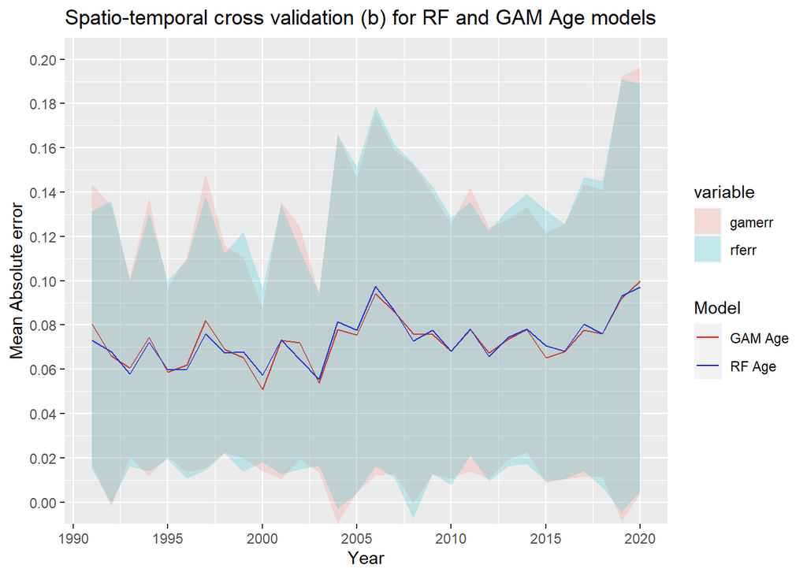

```r
errorPlots("timLocGamAge", "timLocRfAge", "Spatio-temporal cross validation (b) for RF and GAM Age models")
```

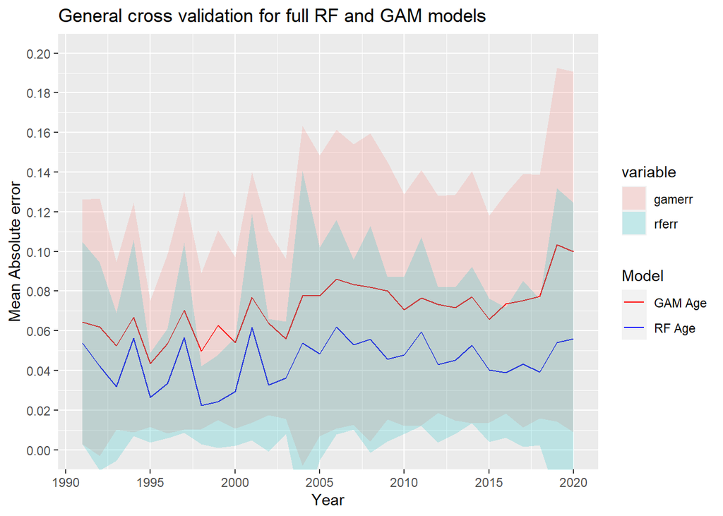

```r
errorPlots("ranGamF", "ranRfF", "General cross validation for full RF and GAM models")
```

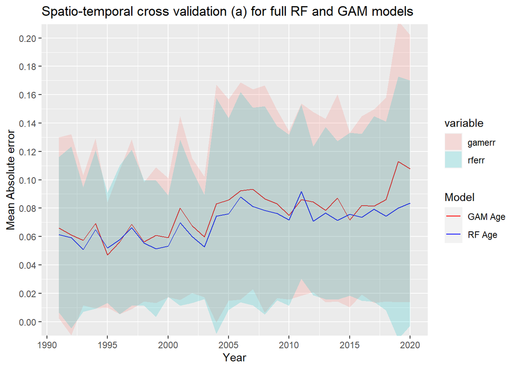

```r
errorPlots("locGamF", "locRfF", "Spatio-temporal cross validation (a) for full RF and GAM models ")
```

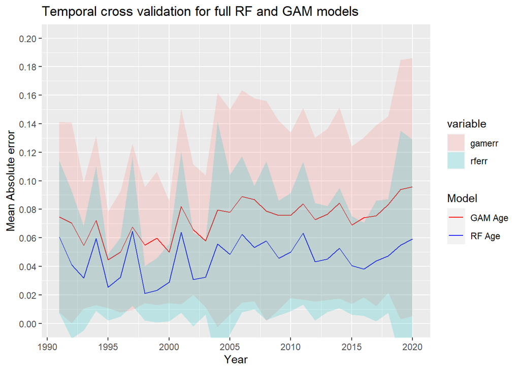

```r
errorPlots("timGamF", "timRfF", "Temporal cross validation for full RF and GAM models")
```

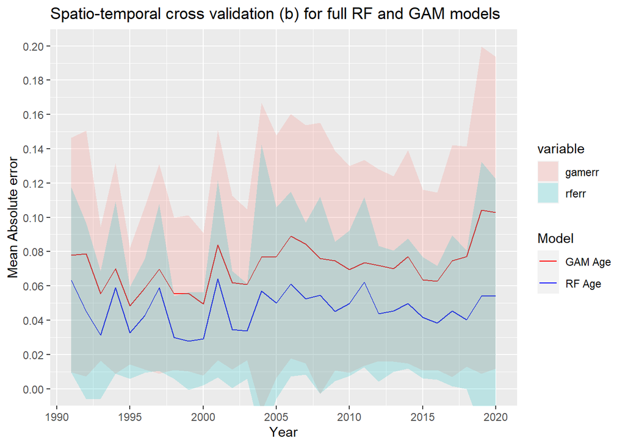

```r
errorPlots("timLocGamF", "timLocRfF", "Spatio-temporal cross validation (b) for full RF and GAM models")
```